# Summary Statistics

The homework assignment is to explore a variable in the attributes dataset. I will look at two year redemptions.

```r
describe(attributes$num_redemptions_2yr)
```

```
attributes$num_redemptions_2yr
       n  missing distinct
  200000        0       59

lowest : ?  0  1  10 11, highest: 7  71 77 8  9
```

There are cases with ‘?’ as a value. In case of redemptions it’s likely that customers with missing values have never redeemed a flight, so I’ll convert these cases to 0.

```r
attributes_clean <- attributes %>%
  mutate(num_redemptions_2yr = as.numeric(ifelse(num_redemptions_2yr=='?',0,num_redemptions_2yr)))
describe(attributes_clean$num_redemptions_2yr)
```

```
attributes_clean$num_redemptions_2yr
       n  missing distinct     Info     Mean      Gmd      .05      .10      .25      .50
  200000        0       58    0.269   0.3726   0.7086        0        0        0        0
     .75      .90      .95
       0        0        2

lowest :  0  1  2  3  4, highest: 57 58 60 71 77
```

These are likely customers who don’t have a loyalty account and so can’t redeem. Let’s check that out

```r
attributes_clean %>%
  group_by(loyalty_status) %>%
  summarise(min = min(num_redemptions_2yr)
            , median = median(num_redemptions_2yr)
            , mean = mean(num_redemptions_2yr)
            , n = n()) %>%
  mutate(pct = n / sum(n))
```

| loyalty_status | min | median | mean | n | pct |
| --- | --- | --- | --- | --- | --- |
| a-list | 0 | 4 | 5.8199052 | 1477 | 0.007385 |
| a-list preferred | 0 | 12 | 14.9836661 | 551 | 0.002755 |
| non-member | 0 | 0 | 0.0000000 | 86764 | 0.433820 |
| rr member | 0 | 0 | 0.5185328 | 111208 | 0.556040 |

My suspicion is confirmed. Non-members have never redeemed a flight, and these customers make up 43% of the population.

Let’s look at the overall distribution of this variale

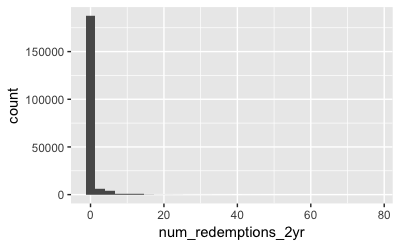

```r
ggplot(attributes_clean, aes(num_redemptions_2yr)) +
  geom_histogram()
```

The vast majority of customers have never redeemed a flight in the past two years. So next I’ll just look at customer who have redeemed

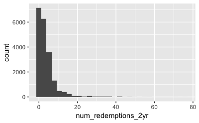

```r
ggplot(attributes_clean %>% filter(num_redemptions_2yr>0), aes(num_redemptions_2yr)) +
  geom_histogram()
```

Even in this scenario the distribution is very right skewed.

Next I’ll look at how these distributions vary by loyalty_status, first getting the data into a tidy form that’s easier to analyze and plot

```r
attributes_tidy <- attributes_clean %>%
  select(fake_id, SEGMENT_ASSIGNED, loyalty_status, num_redemptions_2yr) %>%
  gather(attribute, value, -fake_id, -SEGMENT_ASSIGNED, -loyalty_status)
```

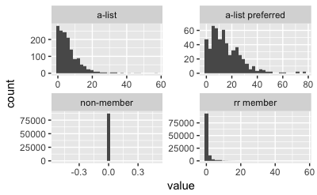

```r
attributes_tidy %>%
  ggplot(aes(value)) %+%
  geom_histogram() %+%
  facet_wrap(~loyalty_status, scales = "free")
```

We see that all non-members have never redeemed and that the skewness of the redeemption distribution declines as we move from the general populatoin “rr member” to the most frequent travelers “a-list prefered”

Let’s look at the same view by segment

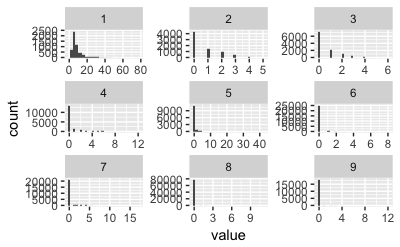

```r
attributes_tidy %>%
  ggplot(aes(value)) +
  geom_histogram() +
  facet_wrap(~SEGMENT_ASSIGNED, scales = "free")
```

Segment 1 has much higher redeemption frequency. Let’s look at the quantiles by segment

```r
attributes_tidy %>%
  group_by(SEGMENT_ASSIGNED) %>%
  summarise(quantiles = paste(round(quantile(value, c(0.01, 0.05, 0.5, 0.95, 0.99), na.rm=TRUE), 2), collapse=",")
            , n = n()
            , redemptions = sum(value)) %>%
  ungroup() %>%
  mutate(pct_redemptions = redemptions / sum(redemptions)) %>%
  extract(quantiles, c("q01", "q05", "q50", "q95", "q99")
          , regex = "(\\d+\\.?\\d*),(\\d+\\.?\\d*),(\\d+\\.?\\d*),(\\d+\\.?\\d*),(\\d+\\.?\\d*)")
```

|  | SEGMENT_ASSIGNED | q01 | q05 | q50 | q95 | q99 | n | redemptions | pct_redemptions |
| --- | --- | --- | --- | --- | --- | --- | --- | --- | --- |
| 1 | 1 | 2 | 3 | 6 | 21 | 36 | 5811 | 47971 | 0.643759142 |
| 2 | 2 | 0 | 0 | 0 | 3 | 3 | 7140 | 4651 | 0.062415288 |
| 3 | 3 | 0 | 0 | 0 | 2 | 4 | 11193 | 6054 | 0.081243206 |
| 4 | 4 | 0 | 0 | 0 | 3 | 5 | 17135 | 7622 | 0.102285385 |
| 5 | 5 | 0 | 0 | 0 | 1 | 3 | 12260 | 1752 | 0.023511414 |
| 6 | 6 | 0 | 0 | 0 | 0 | 2 | 25807 | 1218 | 0.016345263 |
| 7 | 7 | 0 | 0 | 0 | 1 | 4 | 22985 | 3511 | 0.047116765 |
| 8 | 8 | 0 | 0 | 0 | 0 | 0 | 79041 | 1294 | 0.017365165 |
| 9 | 9 | 0 | 0 | 0 | 0 | 1 | 18628 | 444 | 0.005958372 |

Segment one is a small portion of shoppers but makes up 64% of all redemptions. Even the lowest quantiles of segment one have redeemed points in the last two years.